```python
import pandas as pd
import numpy as np
import math
import matplotlib.pyplot as plt
from scipy import stats
from statsmodels import robust
from scipy.stats import wilcoxon
from scipy.stats.mstats import mquantiles
%matplotlib inline
from sklearn.linear_model import LinearRegression
from statsmodels.formula.api import ols
import statsmodels.api as sm
from scipy.interpolate import *
from numpy import *
import scipy as sp
```

```python
lungcap = pd.read_table('C:/Users/Veena Chintala/Desktop/320/LungCapData2.csv', sep=',', header=0)
```

```python
lungcap.head()
```

|  | Age | LungCap | Height | Gender | Smoke |
| --- | --- | --- | --- | --- | --- |
| 0 | 9 | 3.124 | 57.0 | female | no |
| 1 | 8 | 3.172 | 67.5 | female | no |
| 2 | 7 | 3.160 | 54.5 | female | no |
| 3 | 9 | 2.674 | 53.0 | male | no |
| 4 | 9 | 3.685 | 57.0 | male | no |

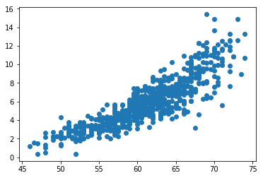

```python
plt.scatter(lungcap['Height'], lungcap['LungCap'])
```

```python
lungcapfit= ols('LungCap ~ Height', data=lungcap).fit()
lungcapfit.summary()
```

OLS Regression Results

| Dep. Variable: | LungCap | R-squared: | 0.754 |
| --- | --- | --- | --- |
| Model: | OLS | Adj. R-squared: | 0.753 |
| Method: | Least Squares | F-statistic: | 1995. |
| Date: | Fri, 02 Nov 2018 | Prob (F-statistic): | 1.57e-200 |
| Time: | 17:04:43 | Log-Likelihood: | -1094.5 |
| No. Observations: | 654 | AIC: | 2193. |
| Df Residuals: | 652 | BIC: | 2202. |
| Df Model: | 1 |  |  |
| Covariance Type: | nonrobust |  |  |

|  | coef | std err | t | P>\|t\| | [0.025 | 0.975] |
| --- | --- | --- | --- | --- | --- | --- |
| Intercept | -18.2980 | 0.544 | -33.613 | 0.000 | -19.367 | -17.229 |
| Height | 0.3959 | 0.009 | 44.662 | 0.000 | 0.379 | 0.413 |

| Omnibus: | 37.490 | Durbin-Watson: | 1.608 |
| --- | --- | --- | --- |
| Prob(Omnibus): | 0.000 | Jarque-Bera (JB): | 91.349 |
| Skew: | 0.284 | Prob(JB): | 1.46e-20 |
| Kurtosis: | 4.740 | Cond. No. | 662. |

Warnings:  
[1] Standard Errors assume that the covariance matrix of the errors is correctly specified.

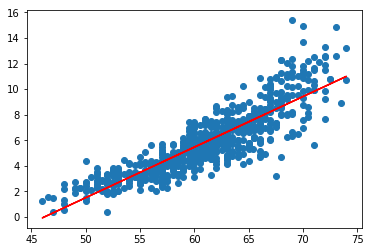

```python
plt.scatter(lungcap['Height'], lungcap['LungCap'])
plt.plot(lungcap['Height'], lungcapfit.fittedvalues, 'r')
```

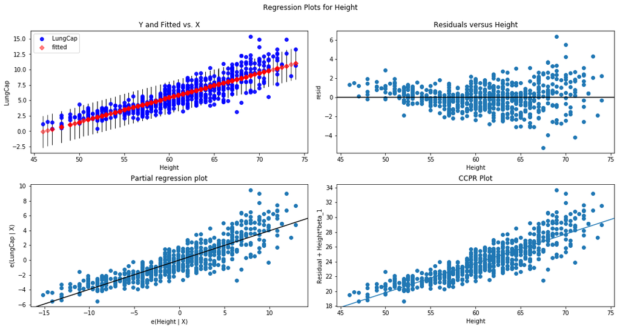

```python
fig = plt.figure(figsize=(15, 8))
fig = sm.graphics.plot_regress_exog(lungcapfit, "Height", fig=fig)
```

### from the plot above we can see that the relation between Lung capacity and Height is non linear.

```python
heightsq = pow(lungcap['Height'],2)
model2= ols('LungCap ~ Height +heightsq', data=lungcap).fit()
model2.summary()
```

OLS Regression Results

| Dep. Variable: | LungCap | R-squared: | 0.774 |
| --- | --- | --- | --- |
| Model: | OLS | Adj. R-squared: | 0.773 |
| Method: | Least Squares | F-statistic: | 1115. |
| Date: | Fri, 02 Nov 2018 | Prob (F-statistic): | 5.01e-211 |
| Time: | 17:04:34 | Log-Likelihood: | -1066.2 |
| No. Observations: | 654 | AIC: | 2138. |
| Df Residuals: | 651 | BIC: | 2152. |
| Df Model: | 2 |  |  |
| Covariance Type: | nonrobust |  |  |

|  | coef | std err | t | P>\|t\| | [0.025 | 0.975] |
| --- | --- | --- | --- | --- | --- | --- |
| Intercept | 16.0806 | 4.510 | 3.566 | 0.000 | 7.226 | 24.936 |
| Height | -0.7501 | 0.150 | -5.015 | 0.000 | -1.044 | -0.456 |
| heightsq | 0.0095 | 0.001 | 7.675 | 0.000 | 0.007 | 0.012 |

| Omnibus: | 34.532 | Durbin-Watson: | 1.611 |
| --- | --- | --- | --- |
| Prob(Omnibus): | 0.000 | Jarque-Bera (JB): | 113.229 |
| Skew: | 0.029 | Prob(JB): | 2.59e-25 |
| Kurtosis: | 5.038 | Cond. No. | 3.57e+05 |

Warnings:  
[1] Standard Errors assume that the covariance matrix of the errors is correctly specified.  
[2] The condition number is large, 3.57e+05. This might indicate that there are  
strong multicollinearity or other numerical problems.

### From the above two models we can see that, when we use only height in the model we get and R-square value of 0.754 and when we include height square in the model the R- squared value of 0.774 it looks like the height squared may be improving the model.

```python
from scipy.interpolate import *
```

```python
p1= polyfit(lungcap['Height'], lungcap['LungCap'],1)
p2 = polyfit(lungcap['Height'], lungcap['LungCap'],2)
p3 = polyfit(lungcap['Height'], lungcap['LungCap'],3)
```

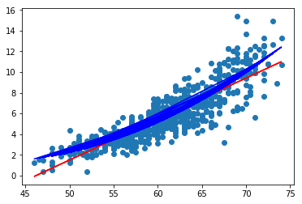

```python
plt.plot(lungcap['Height'], lungcap['LungCap'], 'o')
plt.plot(lungcap['Height'], polyval(p1,lungcap['Height']), 'r-')
plt.plot(lungcap['Height'], polyval(p2,lungcap['Height']), 'b-')
```

### From the above plot we can see that model2 with height squared is fitting better than the model with only height. Let us check with anova if model with height squared is better than model with height.

```python
sm.stats.anova_lm(lungcapfit, model2)
```

[output not shown]

|  | df_resid | ssr | df_diff | ss_diff | F | Pr(>F) |
| --- | --- | --- | --- | --- | --- | --- |
| 0 | 652.0 | 1088.405828 | 0.0 | NaN | NaN | NaN |
| 1 | 651.0 | 998.092326 | 1.0 | 90.313502 | 58.906464 | 6.068515e-14 |

### From above table we can see that p-value is less than 0.05 hence we reject the null hypothesis. In Conclusion we have evidence to believe that model including height square provides a statistically significantly better fit than the model with just height.

```python
heightcube = pow(lungcap['Height'],3)
model3= ols('LungCap ~ Height +heightsq+heightcube ', data=lungcap).fit()
model3.summary()
```

OLS Regression Results

| Dep. Variable: | LungCap | R-squared: | 0.774 |
| --- | --- | --- | --- |
| Model: | OLS | Adj. R-squared: | 0.773 |
| Method: | Least Squares | F-statistic: | 742.7 |
| Date: | Fri, 02 Nov 2018 | Prob (F-statistic): | 1.71e-209 |
| Time: | 17:47:21 | Log-Likelihood: | -1066.1 |
| No. Observations: | 654 | AIC: | 2140. |
| Df Residuals: | 650 | BIC: | 2158. |
| Df Model: | 3 |  |  |
| Covariance Type: | nonrobust |  |  |

|  | coef | std err | t | P>\|t\| | [0.025 | 0.975] |
| --- | --- | --- | --- | --- | --- | --- |
| Intercept | -0.6293 | 38.026 | -0.017 | 0.987 | -75.298 | 74.039 |
| Height | 0.0918 | 1.908 | 0.048 | 0.962 | -3.655 | 3.839 |
| heightsq | -0.0046 | 0.032 | -0.144 | 0.886 | -0.067 | 0.058 |
| heightcube | 7.739e-05 | 0.000 | 0.443 | 0.658 | -0.000 | 0.000 |

| Omnibus: | 34.701 | Durbin-Watson: | 1.611 |
| --- | --- | --- | --- |
| Prob(Omnibus): | 0.000 | Jarque-Bera (JB): | 114.224 |
| Skew: | 0.029 | Prob(JB): | 1.57e-25 |
| Kurtosis: | 5.047 | Cond. No. | 1.91e+08 |

Warnings:  
[1] Standard Errors assume that the covariance matrix of the errors is correctly specified.  
[2] The condition number is large, 1.91e+08. This might indicate that there are  
strong multicollinearity or other numerical problems.

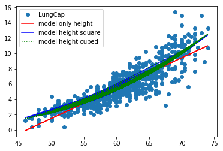

```python
plt.plot(lungcap['Height'], lungcap['LungCap'], 'o')
plt.plot(lungcap['Height'], polyval(p1,lungcap['Height']), 'r-', label='model only height')
plt.plot(lungcap['Height'], polyval(p2,lungcap['Height']), 'b-', label='model height square')
plt.plot(lungcap['Height'], polyval(p3,lungcap['Height']), 'g:', label='model height cubed')
plt.legend()
plt.show()
```

### We can see from the above graph that there is no difference between model with height squared and model with height cubed.

```python
sm.stats.anova_lm(model2, model3)
```

[output not shown]

|  | df_resid | ssr | df_diff | ss_diff | F | Pr(>F) |
| --- | --- | --- | --- | --- | --- | --- |
| 0 | 651.0 | 998.092326 | 0.0 | NaN | NaN | NaN |
| 1 | 650.0 | 997.791669 | 1.0 | 0.300658 | 0.19586 | 0.658231 |

```python
# From the above anova test we see that p-value is greater than 0.05 hence we accept the null hypothesis that there is no
#significant difference between model with height squared and model with height cubed.
```

# In Conclusion: Including Height squared improves the model but Including Height cubed does not improve the model.